# So, just how useless is the U.S. Congress?

# Congressional Productivity

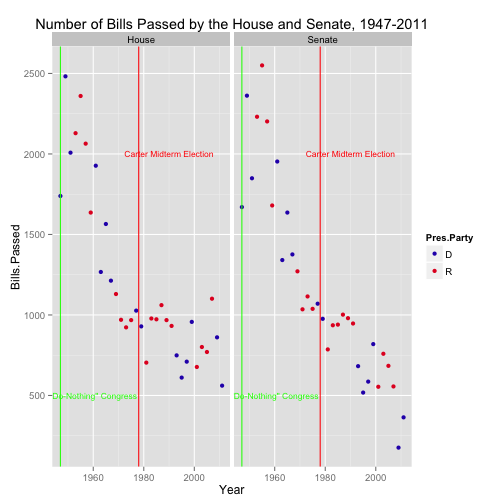

```r
congresses <- read.csv("/Users/samanthatyner/Desktop/585/Project/congress_years.csv")
congresses <- congresses[, -3]
congresses$Congress <- as.numeric(sub("[a-z][a-z]", "", congresses$Congress))
congresses <- cbind(congresses, ldply(strsplit(as.character(congresses$Years),
    "-")))
congresses <- congresses[-2]
names(congresses) <- c("Congress", "Year.Start", "Year.End")
pref <- c(rep(17, 5), "", rep(18, 49), "", rep(19, 49), rep("", 8))
congresses$pref <- pref
congresses$Year.End <- paste(congresses$pref, congresses$Year.End, sep = "")
congresses <- congresses[-4]

# House Workload, 80th-112th Congresses, 1947-2012
house.workload <- readWorksheet(wb6, sheet = "6-1", startRow = 3, endRow = 36)
house.workload$Congress <- 80:112
house.workload <- merge(congresses, house.workload, by = "Congress")
house.workload$Year.Start <- as.numeric(house.workload$Year.Start)
house.workload$Year.End <- as.numeric(house.workload$Year.End)
# Senate Workload, 80th-112th Congresses, 1947-2012
senate.workload <- readWorksheet(wb6, sheet = "6-2", startRow = 3, endRow = 36)
senate.workload$Congress <- 80:112
senate.workload <- merge(congresses, senate.workload, by = "Congress")
senate.workload$Year.Start <- as.numeric(senate.workload$Year.Start)
senate.workload$Year.End <- as.numeric(senate.workload$Year.End)

senate.workload$Office <- "Senate"
house.workload$Office <- "House"
names(house.workload) <- names(senate.workload)
workload <- data.frame(rbind(senate.workload, house.workload))
names(workload) <- c("Congress", "Year", "Year.End", "No.Introduced", "Intro/Member",
    "Bills.Passed", "PassedtoIntroduced", "No.votes", "DaysinSession", "HoursinSession",
    "Hrs/Day.inSession", "Committee", "Office")

names(congresses)[2] <- "Year"
work.yrs <- merge(workload, congresses)
work.yrs.pres <- merge(work.yrs, pres.yr.party, by = "Year")
names(work.yrs.pres)[15] <- "Pres.Party"

ggplot(data = work.yrs.pres) + geom_point(aes(Year, Bills.Passed, color = Pres.Party),
    size = I(2)) + facet_wrap(~Office) + geom_vline(xintercept = 1978, color = "red") +
    geom_vline(xintercept = 1947, color = "green") + scale_color_manual(values = c("#2B07B8",
    "#E30926")) + annotate("text", label = "\"Do-Nothing\" Congress", x = 1960,
    y = 500, size = 3, color = "green") + annotate("text", label = "Carter Midterm Election",
    x = 1990, y = 2000, size = 3, color = "red") + labs(title = "Number of Bills Passed by the House and Senate, 1947-2011")
```

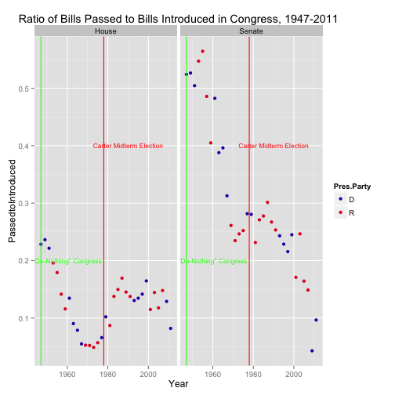

```r
ggplot(data = work.yrs.pres) + geom_point(aes(Year, PassedtoIntroduced, color = Pres.Party),
    size = I(2)) + facet_wrap(~Office) + geom_vline(xintercept = 1978, color = "red") +
    geom_vline(xintercept = 1947, color = "green") + scale_color_manual(values = c("#2B07B8",
    "#E30926")) + annotate("text", label = "\"Do-Nothing\" Congress", x = 1960,
    y = 0.2, size = 3, color = "green") + annotate("text", label = "Carter Midterm Election",
    x = 1990, y = 0.4, size = 3, color = "red") + labs(title = "Ratio of Bills Passed to Bills Introduced in Congress, 1947-2011")
```

## Summary: Congressional Productivity

- Congressional productivity has almost continually decreased since 1949.
- The infamous 'Do-Nothing' congress (the 80th, from 1947-48) is shockingly productive compared to the most recent congress in the data (the 112th, from 2011-12)
- Why has this happened??

# Does Ideology Affect Productivity?

First I look at the relationship between overall ideology in Congress and congressional productivity.

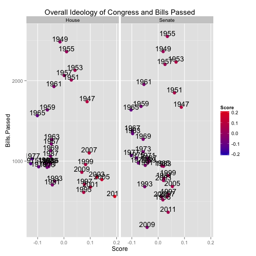

```r
ideols <- filter(ideology, Party == "Entire.chamber")
names(ideols)[2] <- "Year"
ideol.work <- merge(ideols, workload)

ggplot(data = ideol.work, aes(x = Score, y = Bills.Passed)) + geom_point(aes(color = Score),
    size = I(3)) + facet_wrap(~Office) + geom_text(aes(label = Year, y = Bills.Passed +
    40)) + scale_color_gradient(limits = c(-0.2, 0.2), low = "#2B07B8", high = "#E30926") +
    labs(title = "Overall Ideology of Congress and Bills Passed")
```

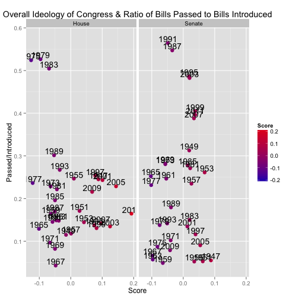

```r
ggplot(data = ideol.work, aes(x = Score, y = ideol.work[, 10])) + geom_point(aes(color = Score),
    size = I(3)) + facet_wrap(~Office) + geom_text(aes(label = Year, y = ideol.work[,
    10] + 0.01)) + scale_color_gradient(limits = c(-0.2, 0.2), low = "#2B07B8",
    high = "#E30926") + labs(title = "Overall Ideology of Congress & Ratio of Bills Passed to Bills Introduced",
    y = "Passed/Introduced")
```

From these plots, it appears that the overall ideology of the Congress does not seem to have a strong or obvious effect on either number of bills passed or on ratio of bill passed to bills introduced.

But, what about the ideological differences between the parties?

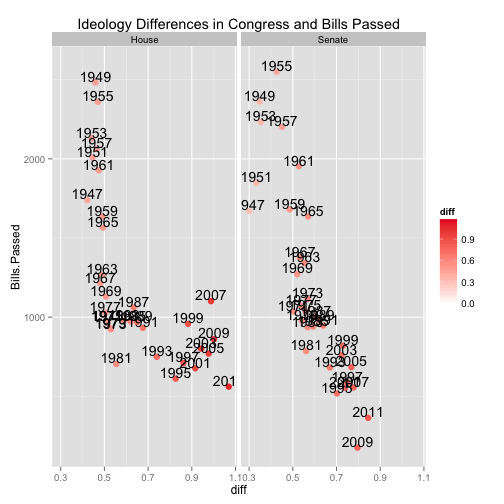

```r
house.ideology <- readWorksheet(wb8, sheet = "8-9", startRow = 3, endRow = 36,
    endCol = 6)
house.ideology$Congress <- gsub("[(,)]", "", house.ideology$Congress)
house.ideology$Congress <- gsub("[a-z][a-z]", "", house.ideology$Congress)
house.ideology <- cbind(house.ideology, ldply(strsplit(house.ideology$Congress,
    "\\s")))
house.ideology <- house.ideology[, c(7, 8, 2:4)]
names(house.ideology) <- c("Congress", "Year", "Entire.chamber", "Democrats",
    "Republicans")
house.ideology$Office <- "House"
senate.ideology <- readWorksheet(wb8, sheet = "8-10", startRow = 3, endRow = 36,
    endCol = 6)
senate.ideology$Congress <- gsub("[(,)]", "", senate.ideology$Congress)
senate.ideology$Congress <- gsub("[a-z][a-z]", "", senate.ideology$Congress)
senate.ideology <- cbind(senate.ideology, ldply(strsplit(senate.ideology$Congress,
    "\\s")))
senate.ideology <- senate.ideology[, c(7, 8, 2:4)]
names(senate.ideology) <- c("Congress", "Year", "Entire.chamber", "Democrats",
    "Republicans")
senate.ideology$Office <- "Senate"
ideols2 <- data.frame(rbind(house.ideology, senate.ideology))

ideols2.work <- merge(ideols2, workload[, c(1, 2, 3, 5, 6, 13)])
ideols2.work$diff <- abs(ideols2.work$Democrats - ideols2.work$Republicans)

ggplot(data = ideols2.work, aes(x = diff, y = Bills.Passed)) + geom_point(aes(color = diff),
    size = I(3)) + facet_wrap(~Office) + geom_text(aes(label = Year, y = Bills.Passed +
    40)) + scale_color_gradient(limits = c(0, 1.2), low = "white", high = "#E30926") +
    labs(title = "Ideology Differences in Congress and Bills Passed")
```

# 2014 Midterm Elections

So, what does this mean for the elections coming up in November of this year?

- We cannot afford to elect more and more extreme candidates to congress. The legislative branch could become completely stalled!
- We cannot let ourselves get sucked into the polarization of American political parties like we have been for the last 30+ years. (See next plot.)

## Polarization of Voters

```r
wb2 <- loadWorkbook("/Users/samanthatyner/Desktop/585/Project/VitalStatisticsFullData/Vital Statistics Chapter 2 - Congressional Elections.xlsx")
party.lines <- readWorksheet(wb2, sheet = "2-19", startRow = 4, endRow = 32,
    endCol = 12)
party.lines <- party.lines[-c(5, 9)]
names(party.lines) <- c("Year", "Pres.partyline", "Pres.defect", "Pres.indep",
    "Sen.partyline", "Sen.defect", "Sen.indep", "House.partyline", "House.defect",
    "House.indep")
party.lines <- melt(party.lines, id = "Year")
party.lines <- party.lines[-which(is.na(party.lines$value)), ]
party.lines <- cbind(party.lines, ldply(strsplit(as.character(party.lines$variable),
    "[.]")))
party.lines <- party.lines[, c(1, 4, 5, 3)]
names(party.lines) <- c("Year", "Type.elec", "Type.voter", "Perc.voters")
party.lines$Type.elec <- as.factor(party.lines$Type.elec)
party.lines$Type.voter <- as.factor(party.lines$Type.voter)
party.lines$Perc.voters <- as.numeric(party.lines$Perc.voters)
```

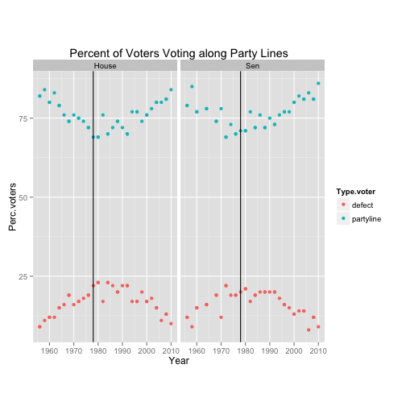

```r
voter.turnout <- readWorksheet(wb2, sheet = "2-1", startRow = 3, endRow = 45,
    endCol = 3)
voter.turnout <- melt(voter.turnout, id = "Year")
names(voter.turnout) <- c("Year", "Election.Type", "Percent")
voter.turnout <- na.omit(voter.turnout)
voter.turnout$Election.Type <- as.character(voter.turnout$Election.Type)
voter.turnout[which(voter.turnout$Election.Type == "House.elections" & voter.turnout$Year %in%
    voter.turnout$Year[which(voter.turnout$Election.Type == "Presidential.elections")]),
    ]$Election.Type <- "On Year"
voter.turnout$Election.Type <- as.factor(voter.turnout$Election.Type)
levels(voter.turnout$Election.Type) <- c("Midterm", "House", "Presidential")
party.lines2 <- merge(party.lines, voter.turnout)
party.lines2$Type.elec <- as.factor(party.lines2$Type.elec)
party.lines2$Type.voter <- as.factor(party.lines2$Type.voter)
party.lines2$Perc.voters <- as.numeric(party.lines2$Perc.voters)
party.lines2$Year <- as.numeric(party.lines2$Year)
party.lines3 <- subset(party.lines2, Type.elec != "Pres")

qplot(Year, Perc.voters, geom = "point", color = Type.voter, data = subset(party.lines3,
    Type.voter != "indep"), size = I(2), main = "Percent of Voters Voting along Party Lines") +
    geom_vline(xintercept = 1978) + facet_wrap(~Type.elec) + coord_fixed(ratio = 1.3)
```

## Will the polarization continue in the 2014 election?

- Look at parties of current candidates
- Compare to parties of incumbents
- See [Party Abbreviations](http://www.fec.gov/finance/disclosure/metadata/DataDictionaryPartyCodeDescriptions.shtml) for help decoding the party labels in the following graphs.

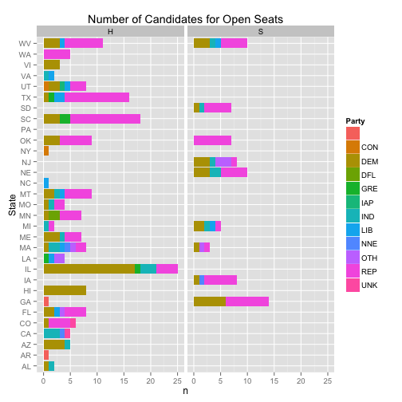

```r
candidates14 <- read.csv("~/Desktop/585/Project/CandidateSummaryAction.csv")
candidates14 <- candidates14[, 3:8]
names(candidates14) <- c("Name", "Office", "State", "District", "Party", "Status")
candidate_info14 <- group_by(candidates14, State, District) %.% arrange(State,
    District, Office)
candidate.open <- filter(candidate_info14, Status == "OPEN") %.% group_by(Office,
    Party)
tot.open <- dplyr::summarise(candidate.open, n = n())

qplot(State, n, data = tot.open, geom = "bar", fill = Party, main = "Number of Candidates for Open Seats") +
    facet_wrap(~Office) + coord_flip()
```

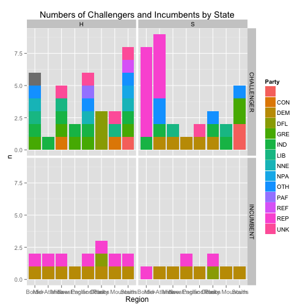

```r
summ.cand <- filter(candidate_info14, Status %in% c("CHALLENGER", "INCUMBENT"),
    Office %in% c("H", "S")) %.% group_by(State, Office, Status, Party) %.%
    dplyr::summarise(n = n())
names(summ.cand)[1] <- "Abbreviation"
summ.cand.reg <- merge(summ.cand, states, by = "Abbreviation")

qplot(data = summ.cand.reg, Region, n, fill = Party, geom = "bar", main = "Numbers of Challengers and Incumbents by State") +
    facet_grid(Status ~ Office)
```

- Based on the amount of pink (Republican candidates) in the previous two plots, it looks like the Democrats will have a hard time holding onto their majority in the senate.
- If the Republicans have the majority in both the House and the Senate in 2015 (they currently have the majority in the House), congressional productivity will likely increase due to party unity.
- But with a Democratic president in his last 2 years, there will also probably be a lot of vetoes, so fewer bills are likely to become law. Support of this claim follows:

## Vetoes

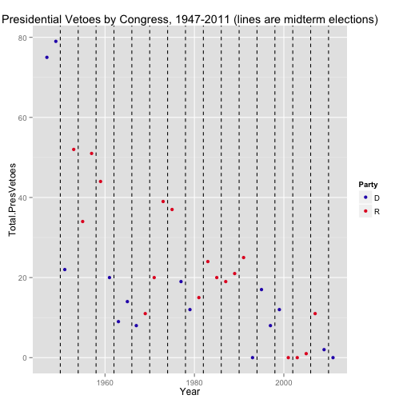

```r
midterm.years <- subset(voter.turnout, Election.Type == "Midterm")$Year
vetoes <- readWorksheet(wb6, sheet = "6-6", startRow = 4, endRow = 37)
vetoes$Congress <- 80:112
names(vetoes) <- c("Congress", "Total.PresVetoes", "Vetoes", "PocketVetoes",
    "Overridden", "Perc.Vetoes", "House.OverrideAttempts", "Senate.OverrideAttempts")
vetoes <- merge(congresses, vetoes)
vetoes <- vetoes[, -3]
names(vetoes) <- c("Congress", "Year", "Total.PresVetoes", "Vetoes", "PocketVetoes",
    "Overridden", "Perc.Vetoes", "House.OverrideAttempts", "Senate.OverrideAttempts")
vetoes <- merge(pres.yr.party, vetoes)
qplot(Year, Total.PresVetoes, data = vetoes, color = Party, main = "Presidential Vetoes by Congress, 1947-2011 (lines are midterm elections)",
    size = I(2)) + scale_color_manual(values = c("#2B07B8", "#E30926")) + geom_vline(xintercept = midterm.years[6:21],
    linetype = "dashed")
```

# Conclusion

I might be letting my personal bias affect my conclusions a little bit, but it really seems that the increased polarization in two-party system is destroying the effectiveness of the United States Congress. To solve this problem, Americans have to have some sort of mass crisis of conscience and come together to fix it (not likely), **or** we need to get rid of the two-party system (also not likely), **or** we dropkick the entire U.S. Congress (just kidding).

Basically, the system is broken, and we have to figure out how to fix it. The best thing we can do about this is learn about the candidates in our district and state and **VOTE** in the midterm election in November. Maybe if we as citizens stop picking the most vitriolic candidates, we will actually have a government that governs someday.

# A Final Note:

So, just how useless is the U.S. Congress?

As it turns out, pretty darn useless.

[figure not shown]